# EDA: Fantasy Points Projections

Initial exploratory pass over the modeling dataset (`data/cached_features.parquet`) before any feature engineering or modeling decisions.

Goals:

- Understand the shape, coverage, and quality of the data
- Characterize the dependent variable (`fantasy_points`) — distribution, by position, over time
- Surface missingness, outliers, and obvious data issues
- Identify which features correlate most with the target, and where multicollinearity lives
- Note anything that should inform modeling choices (transforms, position-specific models, stratification)

```python
import warnings
warnings.filterwarnings("ignore")

import numpy as np
import pandas as pd
import matplotlib.pyplot as plt
import seaborn as sns
from scipy import stats

pd.set_option("display.max_columns", 100)
pd.set_option("display.width", 160)
sns.set_theme(style="whitegrid", context="notebook")

DATA_PATH = "../data/cached_features.parquet"
TARGET = "fantasy_points"
```

## 1. Load data and get oriented

```python
df = pd.read_parquet(DATA_PATH)
print(f"shape: {df.shape}")
df.head()
```

```
shape: (34249, 279)
```

|  | id | player_id | season | week | team | opponent | home_away | games_played | passing_attempts | passing_completions | passing_yards | passing_tds | interceptions | rushing_attempts | rushing_yards | rushing_tds | targets | receptions | receiving_yards | receiving_tds | fumbles | fumbles_lost | two_point_conversions | snap_count | snap_share | team_snaps_x | fantasy_points | created_at | rush_inside_10 | … |
| --- | --- | --- | --- | --- | --- | --- | --- | --- | --- | --- | --- | --- | --- | --- | --- | --- | --- | --- | --- | --- | --- | --- | --- | --- | --- | --- | --- | --- | --- | --- |
| 0 | 67300.0 | 00-0022942 | 2006 | 1 | LAC | LV | unknown | 1.0 | 11.0 | 8.0 | 108.0 | 1.0 | 0.0 | 3.0 | 2.0 | 0.0 | 0.0 | 0.0 | 0.0 | 0.0 | 0.0 | 0.0 | 0.0 | 0.0 | 0.0 | 0.0 | 8.5 | 2026-02-15 16:40:57 | 0.0 | … |
| 1 | 67301.0 | 00-0022942 | 2006 | 2 | LAC | TEN | unknown | 1.0 | 35.0 | 25.0 | 235.0 | 1.0 | 0.0 | 3.0 | 10.0 | 0.0 | 0.0 | 0.0 | 0.0 | 0.0 | 0.0 | 0.0 | 0.0 | 0.0 | 0.0 | 0.0 | 14.4 | 2026-02-15 16:40:57 | 0.0 | … |
| 2 | 67302.0 | 00-0022942 | 2006 | 4 | LAC | BAL | unknown | 1.0 | 22.0 | 13.0 | 145.0 | 1.0 | 1.0 | 1.0 | 0.0 | 0.0 | 0.0 | 0.0 | 0.0 | 0.0 | 0.0 | 0.0 | 0.0 | 0.0 | 0.0 | 0.0 | 7.8 | 2026-02-15 16:40:57 | 0.0 | … |
| 3 | 67303.0 | 00-0022942 | 2006 | 5 | LAC | PIT | unknown | 1.0 | 37.0 | 24.0 | 242.0 | 2.0 | 1.0 | 6.0 | 24.0 | 0.0 | 0.0 | 0.0 | 0.0 | 0.0 | 0.0 | 0.0 | 0.0 | 0.0 | 0.0 | 0.0 | 18.1 | 2026-02-15 16:40:57 | 0.0 | … |
| 4 | 67304.0 | 00-0022942 | 2006 | 6 | LAC | SF | unknown | 1.0 | 39.0 | 29.0 | 334.0 | 2.0 | 0.0 | 2.0 | 2.0 | 0.0 | 0.0 | 0.0 | 0.0 | 0.0 | 0.0 | 0.0 | 0.0 | 0.0 | 0.0 | 0.0 | 21.6 | 2026-02-15 16:40:57 | 0.0 | … |

5 rows × 279 columns

```python
df.dtypes.value_counts()
```

```
float64    268
object       9
int64        2
Name: count, dtype: int64
```

```python
print(f"Seasons: {df['season'].min()}–{df['season'].max()}")
print(f"Weeks per season: {sorted(df['week'].unique())}")
print(f"Positions: {df['position'].value_counts().to_dict()}")
print(f"Unique players: {df['player_id'].nunique()}")
print(f"Unique teams: {df['team'].nunique()}")
```

```
Seasons: 2006–2026
Weeks per season: [1, 2, 3, 4, 5, 6, 7, 8, 9, 10, 11, 12, 13, 14, 15, 16, 17, 18, 19, 20, 21, 22]
Positions: {'WR': 13523, 'RB': 7699, 'TE': 7018, 'QB': 5920, 'K': 57, 'DST': 32}
Unique players: 829
Unique teams: 34
```

```python
rows_per_season = df.groupby("season").size()
fig, ax = plt.subplots(figsize=(10, 4))
rows_per_season.plot(kind="bar", ax=ax, color="#4C72B0")
ax.set_title("Player-week rows per season")
ax.set_xlabel("Season")
ax.set_ylabel("Rows")
plt.tight_layout()
plt.show()
```

[output not shown]

## 2. Missing data overview

Focus on the raw stat columns and target first, then a broader pass across all 279 columns to flag anything mostly-empty.

```python
core_cols = [
    "fantasy_points", "passing_yards", "rushing_yards", "receiving_yards",
    "targets", "receptions", "snap_count", "snap_share", "target_share",
    "air_yards", "utilization_score",
]
df[core_cols].isna().mean().sort_values(ascending=False).to_frame("pct_missing")
```

|  | pct_missing |
| --- | --- |
| fantasy_points | 0.024263 |
| passing_yards | 0.024263 |
| rushing_yards | 0.024263 |
| receiving_yards | 0.024263 |
| targets | 0.024263 |
| receptions | 0.024263 |
| snap_count | 0.024263 |
| snap_share | 0.024263 |
| target_share | 0.024263 |
| air_yards | 0.024263 |
| utilization_score | 0.002599 |

```python
missing_pct = df.isna().mean().sort_values(ascending=False)
print(f"Columns >50% missing: {(missing_pct > 0.5).sum()} / {len(missing_pct)}")
missing_pct[missing_pct > 0.5].head(30).to_frame("pct_missing")
```

```
Columns >50% missing: 50 / 279
```

|  | pct_missing |
| --- | --- |
| team_next_season | 1.000000 |
| predicted_points | 0.975240 |
| projection_18w | 0.975240 |
| projection_4w | 0.975240 |
| projection_1w | 0.975240 |
| td_rate_lag_1 | 0.833046 |
| passer_rating_rolling_3 | 0.833046 |
| rush_attempt_rate_lag_1 | 0.833046 |
| rush_attempt_rate_rolling_3 | 0.833046 |
| int_rate_lag_1 | 0.833046 |
| int_rate_rolling_3 | 0.833046 |
| yards_per_attempt_lag_1 | 0.833046 |
| td_rate_rolling_3 | 0.833046 |
| turnover_rate_lag_1 | 0.833046 |
| yards_per_attempt_rolling_3 | 0.833046 |
| completion_pct_lag_1 | 0.833046 |
| completion_pct_rolling_3 | 0.833046 |
| turnover_rate_rolling_3 | 0.833046 |
| passer_rating_lag_1 | 0.833046 |
| total_plays_rolling_3 | 0.833046 |
| sack_rate_rolling_3 | 0.833046 |
| avg_time_in_pocket_lag_1 | 0.833046 |
| avg_time_in_pocket_rolling_3 | 0.833046 |
| rz_efficiency_rolling_3 | 0.833046 |
| sack_rate_lag_1 | 0.833046 |
| rz_efficiency_lag_1 | 0.833046 |
| deep_ball_pct_lag_1 | 0.833046 |
| deep_ball_pct_rolling_3 | 0.833046 |
| air_yards_per_attempt_lag_1 | 0.833046 |
| air_yards_per_attempt_rolling_3 | 0.833046 |

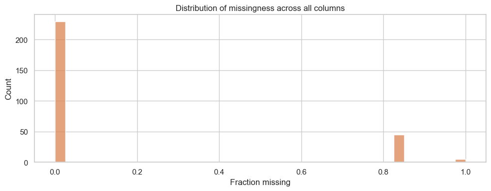

```python
fig, ax = plt.subplots(figsize=(10, 4))
sns.histplot(missing_pct, bins=40, ax=ax, color="#DD8452")
ax.set_title("Distribution of missingness across all columns")
ax.set_xlabel("Fraction missing")
plt.tight_layout()
plt.show()
```

## 3. Dependent variable: `fantasy_points`

```python
target = df[TARGET].dropna()
print(f"n = {len(target)} (dropped {df[TARGET].isna().sum()} NaN)")
target.describe()
```

```
n = 33418 (dropped 831 NaN)
```

```
count    33418.000000
mean         9.953031
std          8.459357
min         -6.700000
25%          3.000000
50%          8.000000
75%         15.100000
max         57.900000
Name: fantasy_points, dtype: float64
```

```python
print(f"skew:    {stats.skew(target):.3f}")
print(f"kurtosis: {stats.kurtosis(target):.3f}")
print(f"zeros:   {(target == 0).mean():.1%}")
print(f"negative: {(target < 0).mean():.1%}")
```

```
skew:    1.041
kurtosis: 0.917
zeros:   5.4%
negative: 0.9%
```

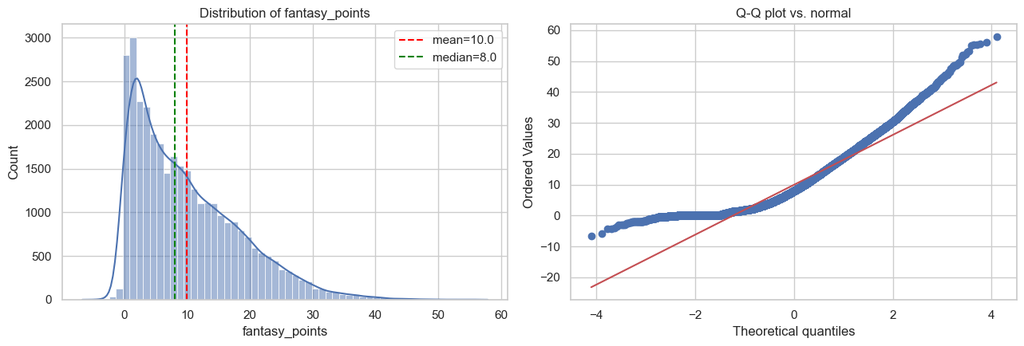

```python
fig, axes = plt.subplots(1, 2, figsize=(13, 4.5))

sns.histplot(target, bins=60, kde=True, ax=axes[0], color="#4C72B0")
axes[0].axvline(target.mean(), color="red", ls="--", label=f"mean={target.mean():.1f}")
axes[0].axvline(target.median(), color="green", ls="--", label=f"median={target.median():.1f}")
axes[0].set_title("Distribution of fantasy_points")
axes[0].legend()

stats.probplot(target, dist="norm", plot=axes[1])
axes[1].set_title("Q-Q plot vs. normal")

plt.tight_layout()
plt.show()
```

### By position

Fantasy scoring differs structurally by position (QBs score differently than RB/WR/TE), so pooling positions is likely wrong for anything beyond a first look.

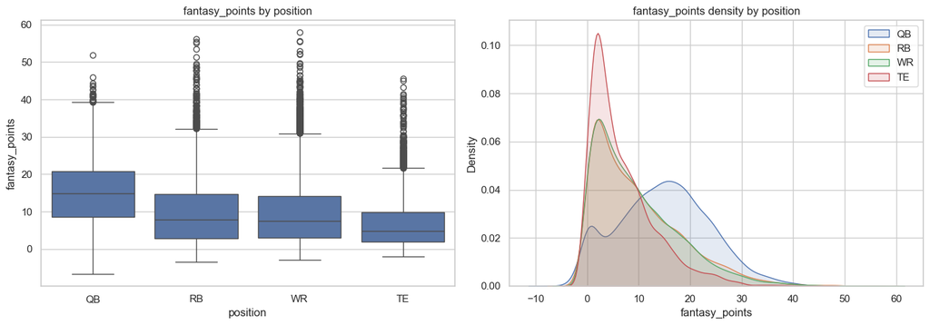

| position | count | mean | std | min | 25% | 50% | 75% | max |
| --- | --- | --- | --- | --- | --- | --- | --- | --- |
| DST | 0.0 | NaN | NaN | NaN | NaN | NaN | NaN | NaN |
| K | 0.0 | NaN | NaN | NaN | NaN | NaN | NaN | NaN |
| QB | 5819.0 | 14.820725 | 8.849481 | -6.7 | 8.5 | 14.9 | 20.8 | 51.9 |
| RB | 7501.0 | 9.827063 | 8.573873 | -3.4 | 2.9 | 7.8 | 14.6 | 56.2 |
| TE | 6871.0 | 6.809213 | 6.389731 | -2.0 | 1.9 | 4.8 | 9.8 | 45.6 |
| WR | 13227.0 | 9.516119 | 8.228265 | -3.0 | 3.0 | 7.5 | 14.2 | 57.9 |

```python
fig, axes = plt.subplots(1, 2, figsize=(14, 5))

sns.boxplot(data=df, x="position", y=TARGET, order=["QB", "RB", "WR", "TE"], ax=axes[0])
axes[0].set_title("fantasy_points by position")

for pos in ["QB", "RB", "WR", "TE"]:
    sub = df.loc[df["position"] == pos, TARGET].dropna()
    sns.kdeplot(sub, ax=axes[1], label=pos, fill=True, alpha=0.15)
axes[1].set_title("fantasy_points density by position")
axes[1].legend()

plt.tight_layout()
plt.show()

df.groupby("position")[TARGET].describe()
```

### Over time

Checking for scoring drift across seasons (rule changes, offensive environment shifts) and within-season patterns (bye weeks, playoff usage change).

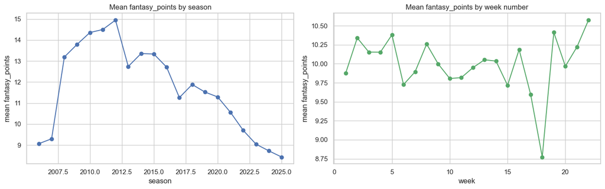

```python
fig, axes = plt.subplots(1, 2, figsize=(14, 4.5))

df.groupby("season")[TARGET].mean().plot(marker="o", ax=axes[0])
axes[0].set_title("Mean fantasy_points by season")
axes[0].set_ylabel("mean fantasy_points")

df.groupby("week")[TARGET].mean().plot(marker="o", ax=axes[1], color="#55A868")
axes[1].set_title("Mean fantasy_points by week number")
axes[1].set_ylabel("mean fantasy_points")

plt.tight_layout()
plt.show()
```

### Outliers

Top and bottom performances — sanity-check these are real games, not data errors.

```python
id_cols = ["name", "position", "team", "opponent", "season", "week", TARGET]
print("Top 10 performances:")
display(df.nlargest(10, TARGET)[id_cols])
print("\nBottom 10 performances:")
display(df.nsmallest(10, TARGET)[id_cols])
```

```
Top 10 performances:
```

|  | name | position | team | opponent | season | week | fantasy_points |
| --- | --- | --- | --- | --- | --- | --- | --- |
| 7590 | T.Hill | WR | KC | TB | 2020 | 12 | 57.9 |
| 11952 | A.Kamara | RB | NO | MIN | 2020 | 16 | 56.2 |
| 24246 | J.Chase | WR | CIN | KC | 2021 | 17 | 55.6 |
| 24292 | J.Chase | WR | CIN | BAL | 2024 | 10 | 55.4 |
| 30872 | J.Gibbs | RB | DET | NYG | 2025 | 12 | 55.4 |
| 11846 | J.Mixon | RB | CIN | CAR | 2022 | 9 | 55.1 |
| 20416 | J.Taylor | RB | IND | BUF | 2021 | 11 | 53.4 |
| 6111 | T.Lockett | WR | SEA | ARI | 2020 | 7 | 53.0 |
| 24271 | J.Chase | WR | CIN | ARI | 2023 | 5 | 52.2 |
| 20261 | G.Davis | WR | BUF | KC | 2021 | 20 | 52.1 |

```
Bottom 10 performances:
```

|  | name | position | team | opponent | season | week | fantasy_points |
| --- | --- | --- | --- | --- | --- | --- | --- |
| 16218 | S.Darnold | QB | NYJ | NE | 2019 | 7 | -6.7 |
| 3114 | G.Smith | QB | NYJ | BUF | 2014 | 8 | -5.8 |
| 31021 | W.Levis | QB | TEN | CIN | 2024 | 15 | -4.4 |
| 24189 | D.Mills | QB | HOU | BUF | 2021 | 4 | -4.3 |
| 3100 | G.Smith | QB | NYJ | BUF | 2013 | 11 | -3.9 |
| 21422 | B.Mann | RB | PHI | TB | 2025 | 4 | -3.4 |
| 1368 | A.Dalton | QB | CIN | BAL | 2017 | 1 | -3.0 |
| 32177 | A.Mitchell | WR | IND | DEN | 2024 | 15 | -3.0 |
| 32985 | M.Brosmer | QB | MIN | SEA | 2025 | 13 | -3.0 |
| 908 | J.Flacco | QB | BAL | JAX | 2017 | 3 | -2.9 |

```python
q1, q3 = target.quantile([0.25, 0.75])
iqr = q3 - q1
lo, hi = q1 - 1.5 * iqr, q3 + 1.5 * iqr
n_outliers = ((target < lo) | (target > hi)).sum()
print(f"IQR fence: [{lo:.1f}, {hi:.1f}]")
print(f"Outliers by 1.5*IQR rule: {n_outliers} ({n_outliers/len(target):.1%})")
```

```
IQR fence: [-15.1, 33.2]
Outliers by 1.5*IQR rule: 469 (1.4%)
```

## 4. Relationship between target and key features

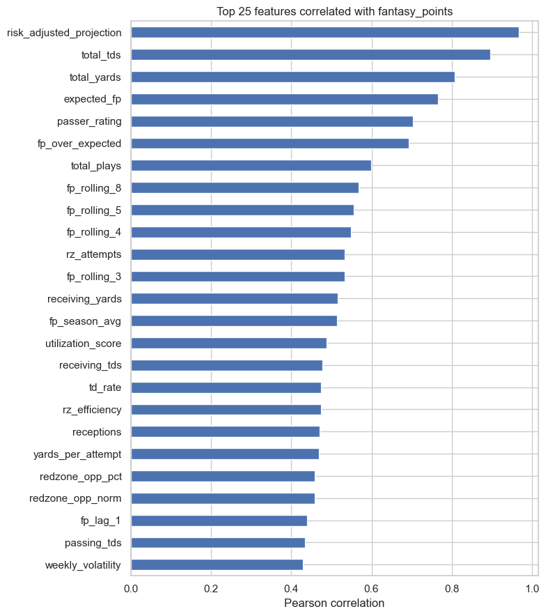

```python
numeric_df = df.select_dtypes(include=[np.number]).drop(columns=[TARGET, "id"], errors="ignore")
corrs = numeric_df.corrwith(df[TARGET]).dropna().sort_values(key=np.abs, ascending=False)

top_n = 25
fig, ax = plt.subplots(figsize=(8, 9))
top_corrs = corrs.head(top_n)
colors = ["#4C72B0" if v > 0 else "#C44E52" for v in top_corrs]
top_corrs.iloc[::-1].plot(kind="barh", ax=ax, color=colors[::-1])
ax.set_title(f"Top {top_n} features correlated with fantasy_points")
ax.set_xlabel("Pearson correlation")
plt.tight_layout()
plt.show()
```

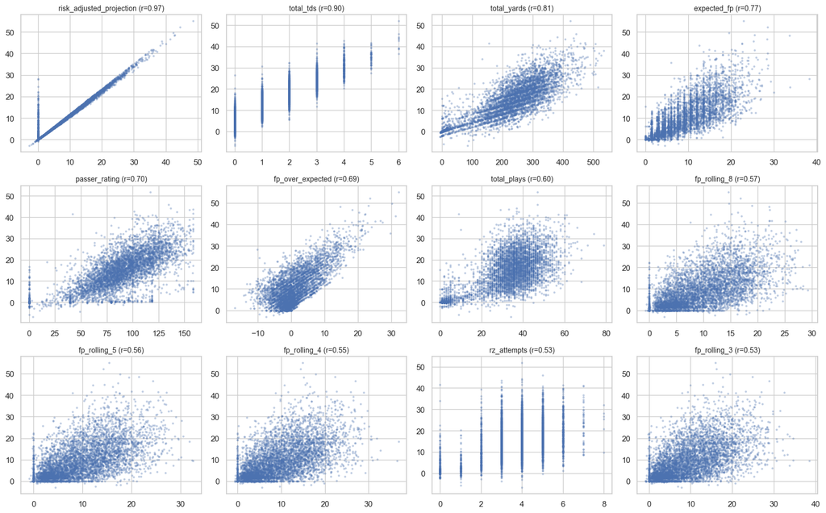

```python
top_feats = corrs.head(12).index.tolist()
fig, axes = plt.subplots(3, 4, figsize=(16, 10))
for ax, feat in zip(axes.flat, top_feats):
    sample = df[[feat, TARGET]].dropna().sample(min(5000, df[feat].notna().sum()), random_state=0)
    ax.scatter(sample[feat], sample[TARGET], s=4, alpha=0.25, color="#4C72B0")
    ax.set_title(f"{feat} (r={corrs[feat]:.2f})", fontsize=10)
plt.tight_layout()
plt.show()
```

## 5. Multicollinearity among top predictors

Cheap check before feature selection / regularization decisions.

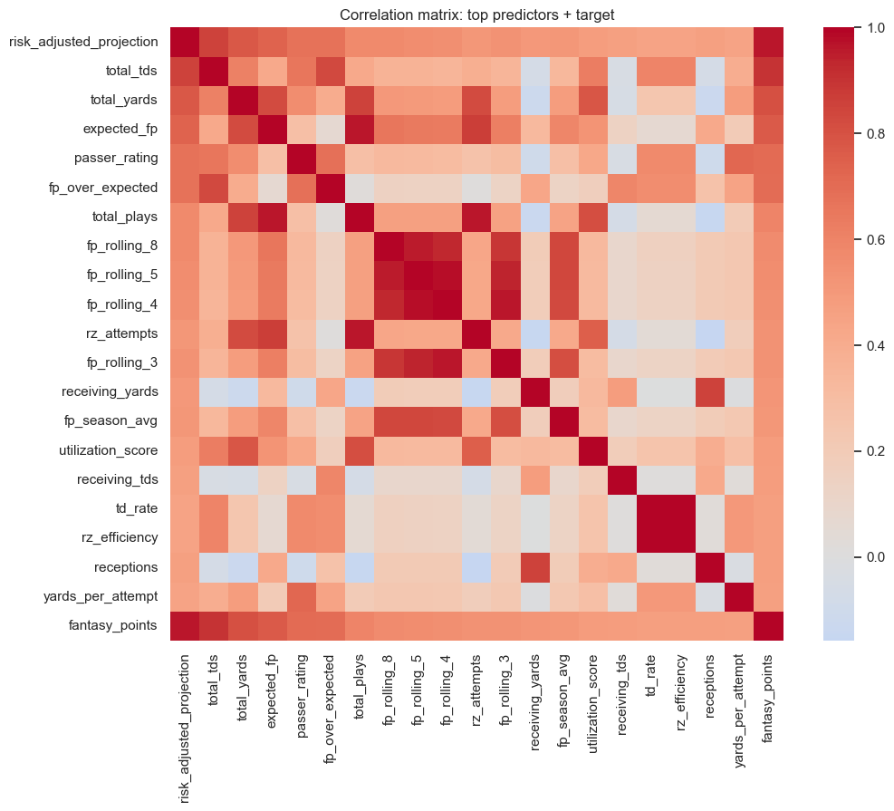

```python
top_feats_20 = corrs.head(20).index.tolist()
corr_matrix = df[top_feats_20 + [TARGET]].corr()

fig, ax = plt.subplots(figsize=(11, 9))
sns.heatmap(corr_matrix, cmap="coolwarm", center=0, annot=False, ax=ax, square=True)
ax.set_title("Correlation matrix: top predictors + target")
plt.tight_layout()
plt.show()
```

## 6. Categorical / structural fields

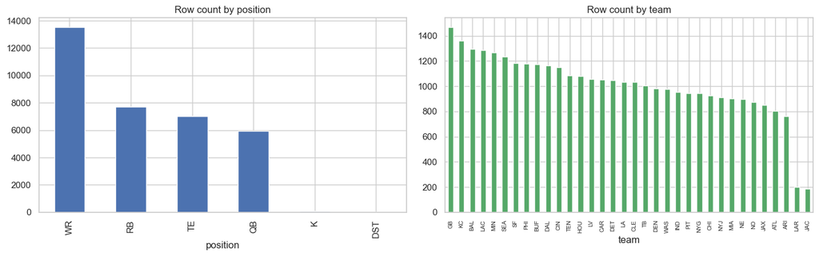

```python
fig, axes = plt.subplots(1, 2, figsize=(14, 4.5))

df["position"].value_counts().plot(kind="bar", ax=axes[0], color="#4C72B0")
axes[0].set_title("Row count by position")

df["team"].value_counts().plot(kind="bar", ax=axes[1], color="#55A868", figsize=(14, 4.5))
axes[1].set_title("Row count by team")
axes[1].tick_params(axis="x", labelsize=7)

plt.tight_layout()
plt.show()
```

```python
playoff_cols = ["is_playoff_week", "is_wild_card", "is_divisional", "is_conference_championship", "is_super_bowl"]
df[playoff_cols].sum().to_frame("row_count")
```

|  | row_count |
| --- | --- |
| is_playoff_week | 1364.0 |
| is_wild_card | 664.0 |
| is_divisional | 414.0 |
| is_conference_championship | 203.0 |
| is_super_bowl | 83.0 |

## 7. Key takeaways

- **Distribution shape**: `fantasy_points` is right-skewed (skew = 1.04, kurtosis = 0.92), floored near 0 with a long tail toward big games — mean 9.95 > median 8.0, 5.4% exact zeros, only 0.9% negative (min -6.7, max 57.9). A log1p transform would help symmetry for a global model, but given how much the shape differs by position, a per-position model is likely a better fix than a transform — consistent with this repo's component-model architecture.
- **Position pooling**: medians differ sharply — QB 14.9, RB 7.8, WR 7.5, TE 4.8 — confirming a single global model is the wrong framing; per-position models are justified.
- **Missingness**: core stat columns (`fantasy_points`, `passing_yards`, `targets`, etc.) are only ~2.4% missing (831 of 34,249 rows) and safe to drop. 50/279 columns are >50% missing, dominated by two groups: (1) `_lag_1`/`_rolling_3` engineered features at 83.3% missing — expected, since they require prior-game history and are NaN for a player's first appearances; confirm downstream code relies on the existing `_imputed`/`_missing` flags rather than silently propagating NaNs — and (2) `projection_*`/`predicted_points` at ~97.5% missing plus `team_next_season` at 100% missing.
- **Leakage risk**: `projection_1w`, `projection_4w`, `projection_18w`, `predicted_points`, `fp_over_expected`, `expected_fp`, and `fp_season_avg` are themselves model outputs or same-window aggregates of the target (`fp_season_avg` correlates 0.51 with the target) — these must be excluded from any "predict this week from prior weeks" feature set to avoid leakage.
- **Outliers**: top performances (T.Hill 57.9, A.Kamara 56.2, J.Chase 55.6/55.4/52.2, J.Gibbs 55.4) are real WR/RB explosion games, not data errors. Bottom performances are almost all QBs with multi-INT/fumble disasters (S.Darnold -6.7, G.Smith -5.8) — also legitimate. The 1.5×IQR rule flags 469 rows (1.4%) as outliers, all of which look like genuine extreme performances rather than data quality issues, so no filtering/winsorizing needed.
- **Top correlated features**: `risk_adjusted_projection` (r=0.97) and `expected_fp` (r=0.77) are themselves projections/leakage risks (see above, exclude from causal features). Beyond those, the strongest legitimate predictors are `total_tds` (0.90), `total_yards` (0.81), `passer_rating` (0.70), and usage signals like `total_plays` (0.60), `rz_attempts` (0.53), `receiving_yards` (0.52), and `utilization_score` (0.49) — all match domain intuition (volume + red zone usage + scoring drive fantasy points), not leakage.